# ECI 511 – Week 1 Review

ECI511

NC State

government

history

industry

military

portfolio

revolution

webpage

design

inquiry

leadership

Week 1 gave us an opportunity to meet the class and served as an introduction to the field of learning design and technology.

James Hardaway https://scholar.google.com/citations?user=su16JUQAAAAJ&hl=en&authuser=1  
2021-07-04

For my intro to the Learning Design & Technology (LDT) program, I’m taking one 5-week summer class before going full time in the fall. ECI 511, Intro to LDT, is the recommended first course for the program and for good reason. The compressed schedule is designed to give a thorough, but quick, overview of the 3 core disciplines within the field of LDT: Leadership, Design, and Digital Inquiry. Here in week 1, we focused on how the LDT field has been established historically mainly driven by the technological revolution.

## Reading/Videos

The class material has a good mix of articles and videos to introduce us to how the field has evolved over the past 100 years. There is a major assignment each week and for this first week, my assignment was to establish this portfolio website. The intent is for me to use this portal to chart my progress through the program, displaying my work as well as what I’m learning by doing the work. The end state is to have a portfolio showing my progress in becoming a learning designer that could potentially be used as a launching point for my life after the program. Through this week’s class material, my key insights are below:

- Tech changes to education came from outside the school house (government, military, industry)
- The speed of tech evolution (capability/capacity) is always under-valued/appreciated
- Tech’s ability to “revolutionize” learning has always been over-emphasized
- Educational institutions are generally slow to adopt new technology/methods
- Historically, tech’s impact to learning has been on the margins (pencils/paper/blackboards becoming digitized), but we have yet to see a “revolution” in how we teach/learn.

## Discussion

For our first discussion topic, each student was asked to provide an introduction and photo so we can better visualize who we’ll be working with this semester. The introduction should Include current job role, goal or rationale for entering the Learning, Design, and Technology master’s program, and interests in the field. Finally, after perusing this week’s readings, we were asked to craft a personal definition of the instructional technology/instructional design field. The goal is to see how much our perceptions and or knowledge of the field change throughout the course, and we will have an opportunity to revisit the definition at the end of the semester to correct any misconceptions. Below is my intro to the class:

[figure not shown]

Hello, fellow Wolfpackers! My name is James Hardaway and I’m new to the education and learning design field. I’m returning to NCSU after a bit of a detour as an Army officer. I will retire this week, so it’s fitting to come back to my roots as my military career began here with my graduation and commissioning back in 1994. I’ve spent 27 years as an Army intelligence officer, so I’m versed in data-driven analysis, critical thinking, and leadership development. My goal in the LD&T master’s program is to explore how digital learning tools can assist in discovering how students receive instruction and learn. I’m a parent of a high school senior who is in his 10th school. To say we’ve seen a wide variety of teaching methodologies is a huge understatement. These experiences have highlighted a gap (at least in public education) in how to determine a student’s learning path to best maximize outcomes for the individual. I want to play a role in developing tools (software/hardware) and designing curricula that bridge this gap.

To me, the instructional technology/instructional design field combines advances in multi-media educational instruments/aids with various teaching modalities to improve the learning experience.

## Assignments

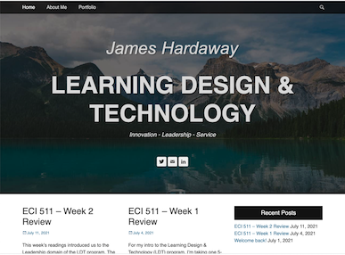

Our first graded assignment is to create a website framework that we’ll be using for our digital program portfolio. The [guidelines](https://github.com/jmhardaw/LDT-portfolio/blob/main/content/portfolio-guidelines.pdf) are fairly broad and allow us to use any tools we’re confident can enable us to build a site that demonstrates the skills and abilities we’ve acquired throughout the program. The completed portfolio will be submitted as part of ECI 652, our final course. I have some experience with [WordPress](https://wordpress.ncsu.edu/) and building websites, so I began there. For this initial assignment, we are only required to develop the basic structure for the online portfolio. That effort resides [here](https://jmhardaw.wordpress.ncsu.edu/). I’m sure this site will evolve often and look much different by the time I complete the program.